# White Wine Alcohol Analysis by Subha Radhakrishnan

[output not shown]

Input variables (based on physicochemical tests): 1 - fixed acidity (tartaric acid - g / dm^3) 2 - volatile acidity (acetic acid - g / dm^3) 3 - citric acid (g / dm^3) 4 - residual sugar (g / dm^3) 5 - chlorides (sodium chloride - g / dm^3 6 - free sulfur dioxide (mg / dm^3) 7 - total sulfur dioxide (mg / dm^3) 8 - density (g / cm^3) 9 - pH 10 - sulphates (potassium sulphate - g / dm3) 11 - alcohol (% by volume) Output variable (based on sensory data): 12 - quality (score between 0 and 10)

Description of attributes:

1 - fixed acidity: most acids involved with wine or fixed or nonvolatile (do not evaporate readily)

2 - volatile acidity: the amount of acetic acid in wine, which at too high of levels can lead to an unpleasant, vinegar taste

3 - citric acid: found in small quantities, citric acid can add ‘freshness’ and flavor to wines

4 - residual sugar: the amount of sugar remaining after fermentation stops, it’s rare to find wines with less than 1 gram/liter and wines with greater than 45 grams/liter are considered sweet

5 - chlorides: the amount of salt in the wine

6 - free sulfur dioxide: the free form of SO2 exists in equilibrium between molecular SO2 (as a dissolved gas) and bisulfite ion; it prevents microbial growth and the oxidation of wine

7 - total sulfur dioxide: amount of free and bound forms of S02; in low concentrations, SO2 is mostly undetectable in wine, but at free SO2 concentrations over 50 ppm, SO2 becomes evident in the nose and taste of wine

8 - density: the density of water is close to that of water depending on the percent alcohol and sugar content

9 - pH: describes how acidic or basic a wine is on a scale from 0 (very acidic) to 14 (very basic); most wines are between 3-4 on the pH scale

10 - sulphates: a wine additive which can contribute to sulfur dioxide gas (S02) levels, wich acts as an antimicrobial and antioxidant

11 - alcohol: the percent alcohol content of the wine

Output variable (based on sensory data): 12 - quality (score between 0 and 10)

#### Univariate Plots Section

```
## [1] 4898   13
```

```
##  [1] "X"                    "fixed.acidity"        "volatile.acidity"
##  [4] "citric.acid"          "residual.sugar"       "chlorides"
##  [7] "free.sulfur.dioxide"  "total.sulfur.dioxide" "density"
## [10] "pH"                   "sulphates"            "alcohol"
## [13] "quality"
```

```
##   X fixed.acidity volatile.acidity citric.acid residual.sugar chlorides
## 1 1           7.0             0.27        0.36           20.7     0.045
## 2 2           6.3             0.30        0.34            1.6     0.049
## 3 3           8.1             0.28        0.40            6.9     0.050
## 4 4           7.2             0.23        0.32            8.5     0.058
## 5 5           7.2             0.23        0.32            8.5     0.058
## 6 6           8.1             0.28        0.40            6.9     0.050
##   free.sulfur.dioxide total.sulfur.dioxide density   pH sulphates alcohol
## 1                  45                  170  1.0010 3.00      0.45     8.8
## 2                  14                  132  0.9940 3.30      0.49     9.5
## 3                  30                   97  0.9951 3.26      0.44    10.1
## 4                  47                  186  0.9956 3.19      0.40     9.9
## 5                  47                  186  0.9956 3.19      0.40     9.9
## 6                  30                   97  0.9951 3.26      0.44    10.1
##   quality
## 1       6
## 2       6
## 3       6
## 4       6
## 5       6
## 6       6
```

```
##        X        fixed.acidity    volatile.acidity  citric.acid
##  Min.   :   1   Min.   : 3.800   Min.   :0.0800   Min.   :0.0000
##  1st Qu.:1225   1st Qu.: 6.300   1st Qu.:0.2100   1st Qu.:0.2700
##  Median :2450   Median : 6.800   Median :0.2600   Median :0.3200
##  Mean   :2450   Mean   : 6.855   Mean   :0.2782   Mean   :0.3342
##  3rd Qu.:3674   3rd Qu.: 7.300   3rd Qu.:0.3200   3rd Qu.:0.3900
##  Max.   :4898   Max.   :14.200   Max.   :1.1000   Max.   :1.6600
##  residual.sugar     chlorides       free.sulfur.dioxide
##  Min.   : 0.600   Min.   :0.00900   Min.   :  2.00
##  1st Qu.: 1.700   1st Qu.:0.03600   1st Qu.: 23.00
##  Median : 5.200   Median :0.04300   Median : 34.00
##  Mean   : 6.391   Mean   :0.04577   Mean   : 35.31
##  3rd Qu.: 9.900   3rd Qu.:0.05000   3rd Qu.: 46.00
##  Max.   :65.800   Max.   :0.34600   Max.   :289.00
##  total.sulfur.dioxide    density             pH          sulphates
##  Min.   :  9.0        Min.   :0.9871   Min.   :2.720   Min.   :0.2200
##  1st Qu.:108.0        1st Qu.:0.9917   1st Qu.:3.090   1st Qu.:0.4100
##  Median :134.0        Median :0.9937   Median :3.180   Median :0.4700
##  Mean   :138.4        Mean   :0.9940   Mean   :3.188   Mean   :0.4898
##  3rd Qu.:167.0        3rd Qu.:0.9961   3rd Qu.:3.280   3rd Qu.:0.5500
##  Max.   :440.0        Max.   :1.0390   Max.   :3.820   Max.   :1.0800
##     alcohol         quality
##  Min.   : 8.00   Min.   :3.000
##  1st Qu.: 9.50   1st Qu.:5.000
##  Median :10.40   Median :6.000
##  Mean   :10.51   Mean   :5.878
##  3rd Qu.:11.40   3rd Qu.:6.000
##  Max.   :14.20   Max.   :9.000
```

```
## 'data.frame':    4898 obs. of  13 variables:
##  $ X                   : int  1 2 3 4 5 6 7 8 9 10 ...
##  $ fixed.acidity       : num  7 6.3 8.1 7.2 7.2 8.1 6.2 7 6.3 8.1 ...
##  $ volatile.acidity    : num  0.27 0.3 0.28 0.23 0.23 0.28 0.32 0.27 0.3 0.22 ...
##  $ citric.acid         : num  0.36 0.34 0.4 0.32 0.32 0.4 0.16 0.36 0.34 0.43 ...
##  $ residual.sugar      : num  20.7 1.6 6.9 8.5 8.5 6.9 7 20.7 1.6 1.5 ...
##  $ chlorides           : num  0.045 0.049 0.05 0.058 0.058 0.05 0.045 0.045 0.049 0.044 ...
##  $ free.sulfur.dioxide : num  45 14 30 47 47 30 30 45 14 28 ...
##  $ total.sulfur.dioxide: num  170 132 97 186 186 97 136 170 132 129 ...
##  $ density             : num  1.001 0.994 0.995 0.996 0.996 ...
##  $ pH                  : num  3 3.3 3.26 3.19 3.19 3.26 3.18 3 3.3 3.22 ...
##  $ sulphates           : num  0.45 0.49 0.44 0.4 0.4 0.44 0.47 0.45 0.49 0.45 ...
##  $ alcohol             : num  8.8 9.5 10.1 9.9 9.9 10.1 9.6 8.8 9.5 11 ...
##  $ quality             : int  6 6 6 6 6 6 6 6 6 6 ...
```

My goal is to associate quality to the wines based on the alcohol , density and residual sugar. In this journey I may analyse other vraiables also depending on the study of plots. I changed the names of attributes to accomodate them on the plots.

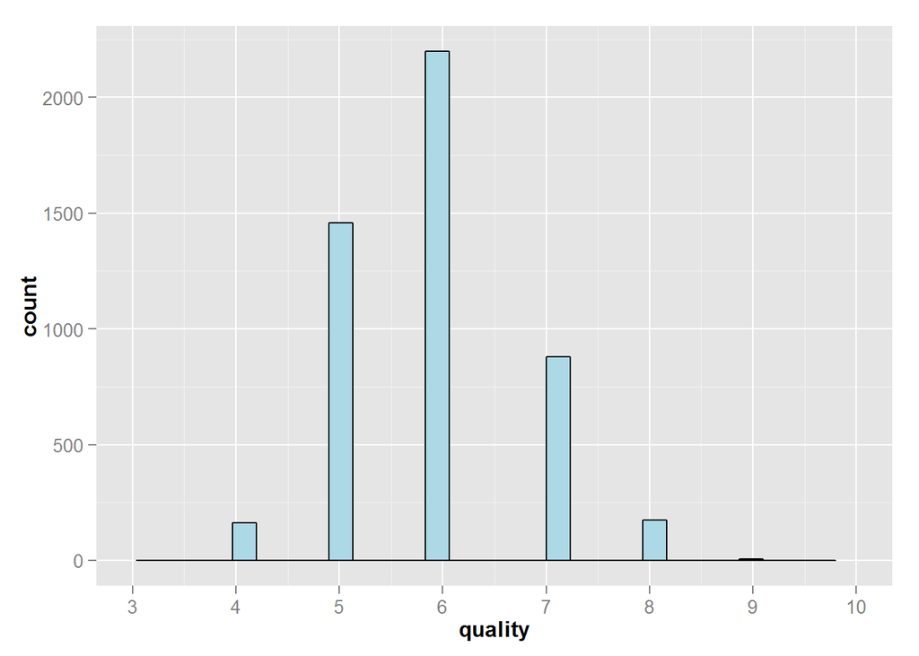

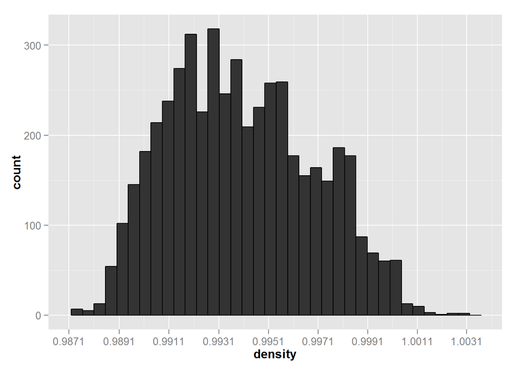

Summary gives the mean and median with minimum and maximum values.

```
##    Min. 1st Qu.  Median    Mean 3rd Qu.    Max.
##  0.0800  0.2100  0.2600  0.2782  0.3200  1.1000
```

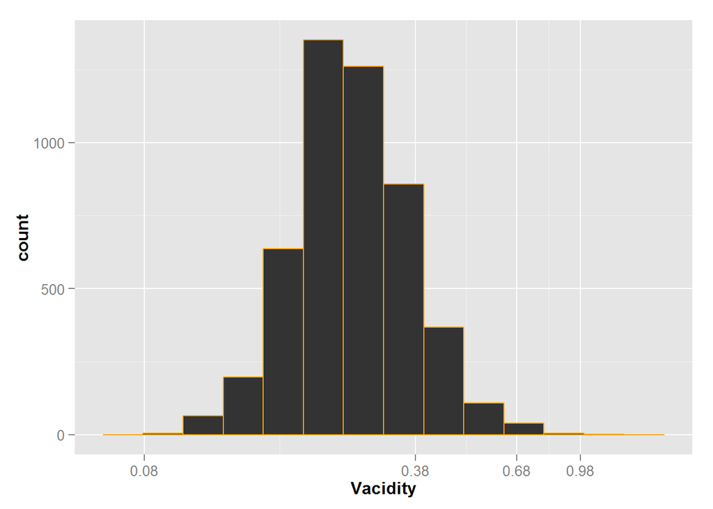

Volatile acidity-All wines contain volatile acidity and it contributes to the overall acidity and aroma of wines. Volatile acidity has normal distribution. It indicates that high acidity levels can decrease the taste and that is why there is always a medium balance.

```
##    Min. 1st Qu.  Median    Mean 3rd Qu.    Max.
##    8.00    9.50   10.40   10.51   11.40   14.20
```

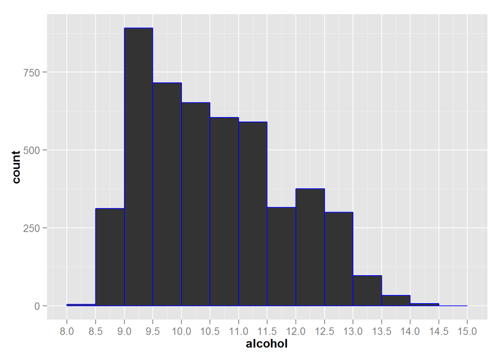

Alcohol level distribution looks skewed. Most frequently wines have 9.5%.Mean is 10.51% of alcohol.

```
##    Min. 1st Qu.  Median    Mean 3rd Qu.    Max.
##   0.600   1.700   5.200   6.391   9.900  65.800
```

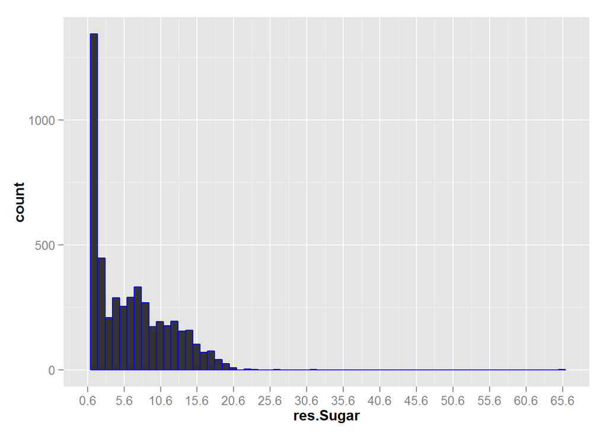

Mostly white wines has less residual sugar. To make sure my analysis is right, I checked if there are wines with residual Sugar > 45 which denotes they are sweet. I could find only 1 wine with this composition. Hence I understood that most wines have less sweet and may be more alcohol!

```
##    Min. 1st Qu.  Median    Mean 3rd Qu.    Max.
##     9.0   108.0   134.0   138.4   167.0   440.0
```

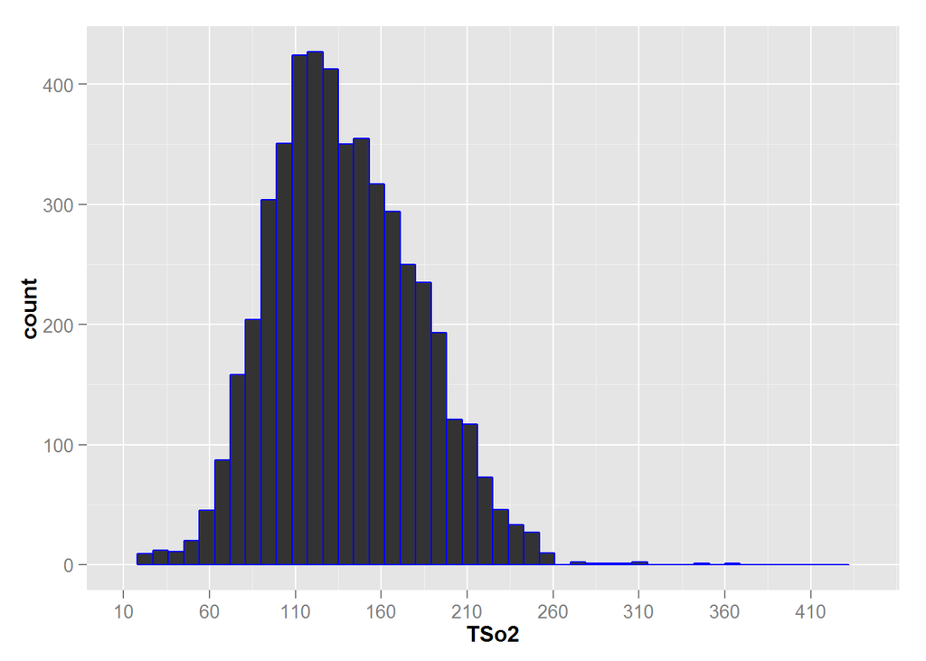

#### What other features in the dataset do you think will help support your investigation into your feature(s) of interest?

From the description of variables in the dataset,few of the variables that I felt will support investigation are:

Volatile Acidity : Can lead to vinegar taste in high quantity Residual Sugar : To determinie the sweetness of a wine Free Sulfur Dioxide : Seems to become evident after a certain amount Chloride: Amount of salt in wine Alcochol content in wine density:density of water close to water based on alcohol

#### Did you create any new variables from existing variables in the dataset?

Based on the descriptions to the variable total sulfur dioxide(amount of free and bound forms of S02), I decided to create a variable that holds the bound forms of S02 as we already have free form.

wines$bound.sulfur.dioxide<- wines$total.sulfur.dioxide-wines$free.sulfur.dioxide

#### Of the features you investigated, were there any unusual distributions? Did you perform any operations on the data to tidy, adjust, or change the form of the data? If so, why did you do this?

I felt the positive skewed data on alcohol as unusual because my belief was that white wines contain more alcohol in it.But from the diagram it seems on a average is less than the highest alcohol content. After I ran the ggpairs to understand the correlation, I thought it will be good to shorten the names of variables.The rest of the data were are looking good and no transformation seem to be needed expliciltly.

#### Bivariate Plots Section

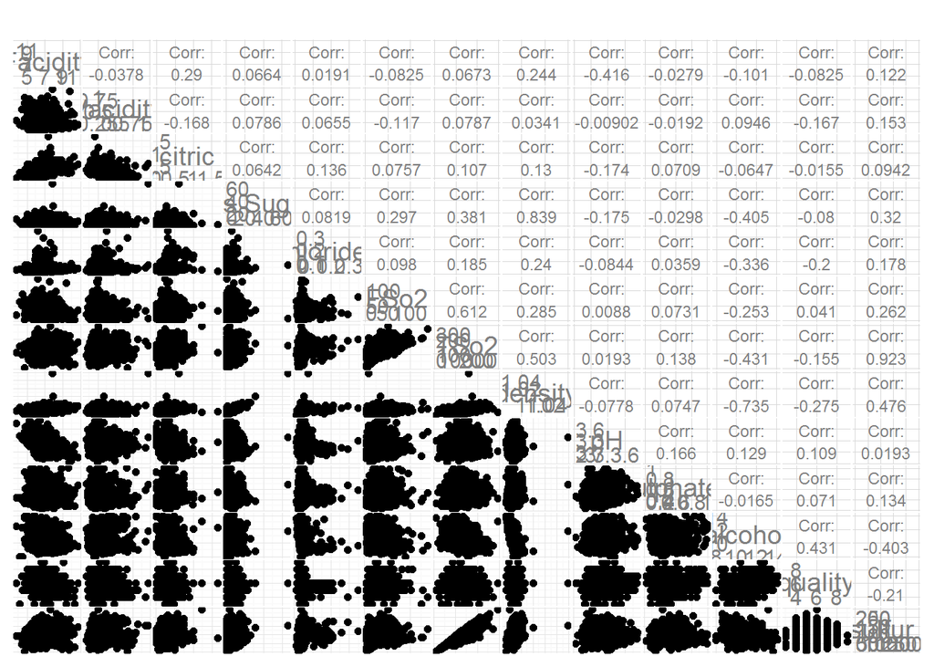

Correlation : -0.354

```
##    Min. 1st Qu.  Median    Mean 3rd Qu.    Max.
##   3.000   5.000   6.000   5.878   6.000   9.000
```

```
##    Min. 1st Qu.  Median    Mean 3rd Qu.    Max.
##  0.9871  0.9917  0.9937  0.9940  0.9961  1.0390
```

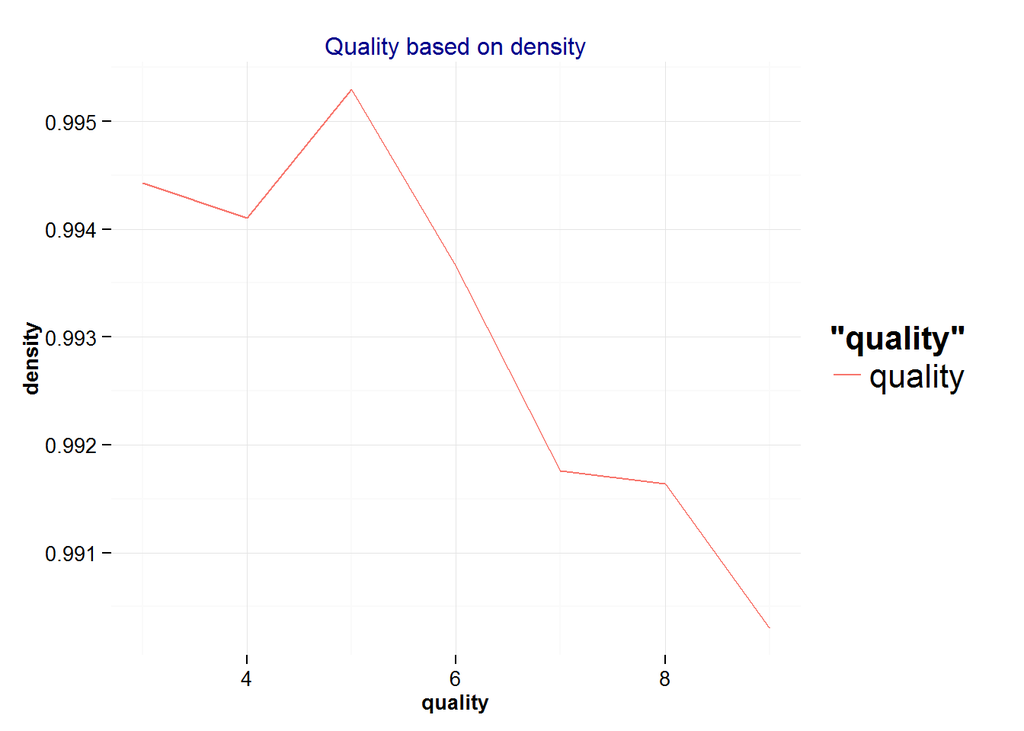

From the plot above, less dense the wine, the quality is good. Now, I would need to understand how density is related to other varaiables.

Correlation : 0.826

```
##    Min. 1st Qu.  Median    Mean 3rd Qu.    Max.
##   0.600   1.700   5.200   6.391   9.900  65.800
```

```
##    Min. 1st Qu.  Median    Mean 3rd Qu.    Max.
##  0.9871  0.9917  0.9937  0.9940  0.9961  1.0390
```

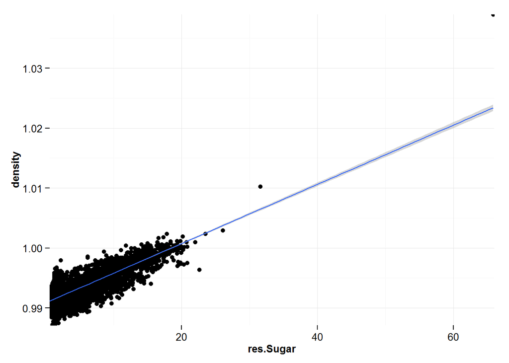

Residual Sugar and density go to-gether.

Correlation : -0.804

```
##    Min. 1st Qu.  Median    Mean 3rd Qu.    Max.
##    8.00    9.50   10.40   10.51   11.40   14.20
```

```
##    Min. 1st Qu.  Median    Mean 3rd Qu.    Max.
##  0.9871  0.9917  0.9937  0.9940  0.9961  1.0390
```

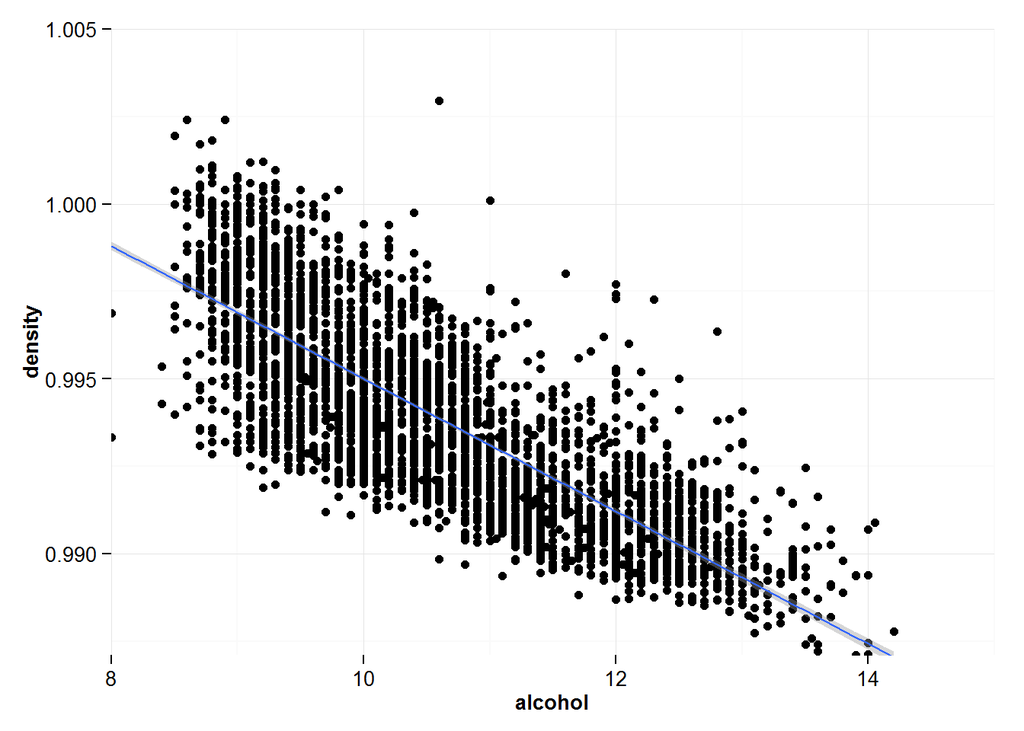

The above plot shows that less dense ,the more the amount of alcohol in the wine.

Correlation : residual sugar vs alcohol= -0.447

Correlation : residual sugar vs quality= -0.117

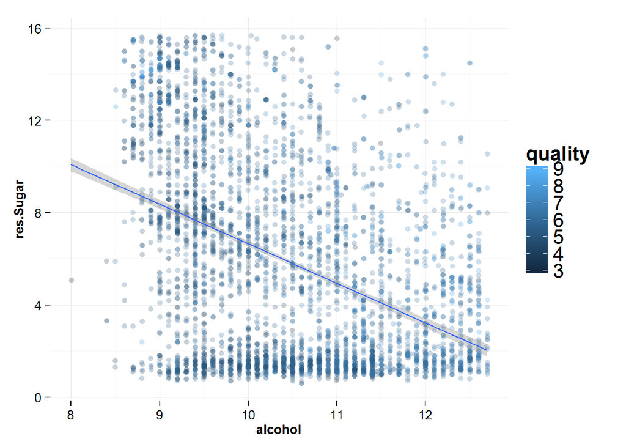

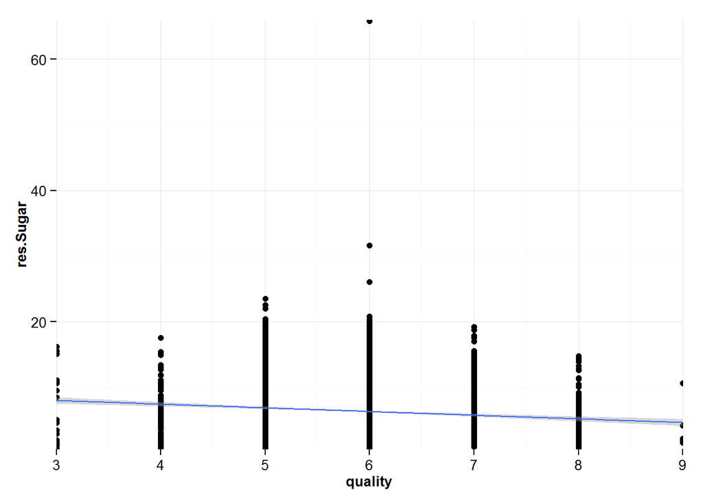

Less residual sugar is present on high alcohol content . Quality of wine is also high if residual sugar is less.

Correlation : TSo2 vs alcohol= -0.464

Correlation : TSo2 vs quality= -0.179

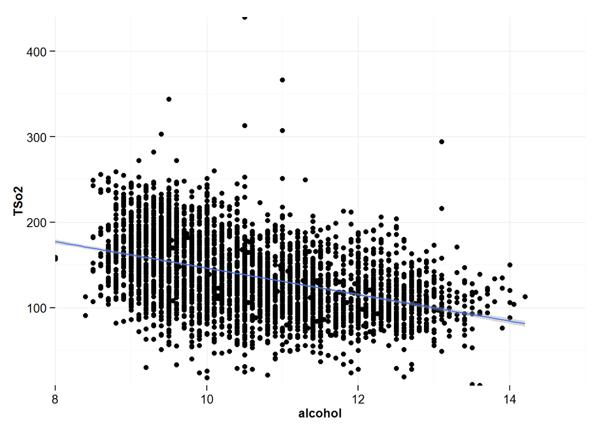

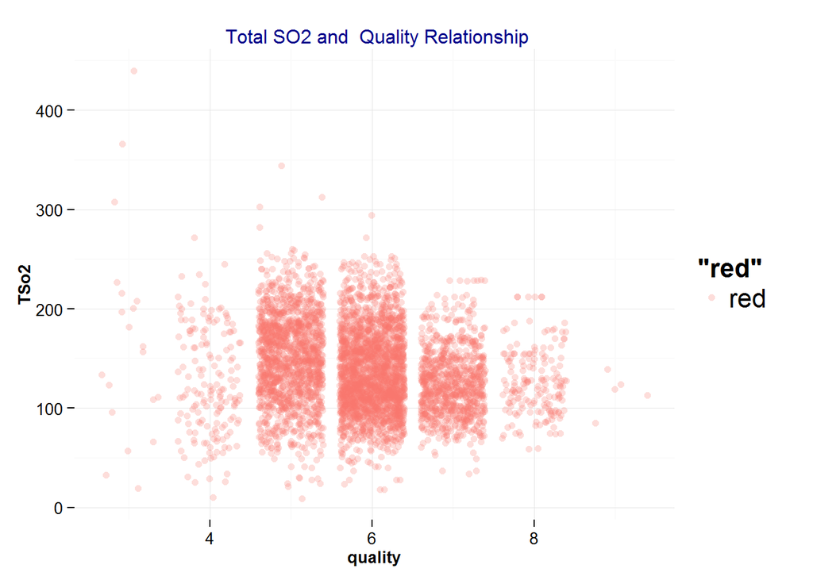

Total SO2 content decreases with Alcohol content for White wine.It is clear that the quality of wine is good with less Sulfur dioxide

Correlation : Chlorides vs quality= -0.25

```
##    Min. 1st Qu.  Median    Mean 3rd Qu.    Max.
## 0.00900 0.03600 0.04300 0.04577 0.05000 0.34600
```

```
##    Min. 1st Qu.  Median    Mean 3rd Qu.    Max.
##   3.000   5.000   6.000   5.878   6.000   9.000
```

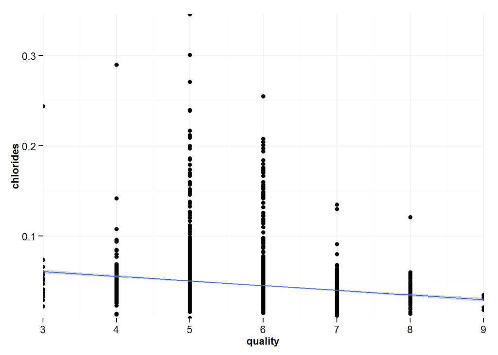

I decided to look at chlorides and residual sugar to see how they are related since I thought they cannot exist in similar quantities.

Correlation : Chlorides vs residual sugar= 0.0965

Correlation : Chlorides vs alcohol= -0.361

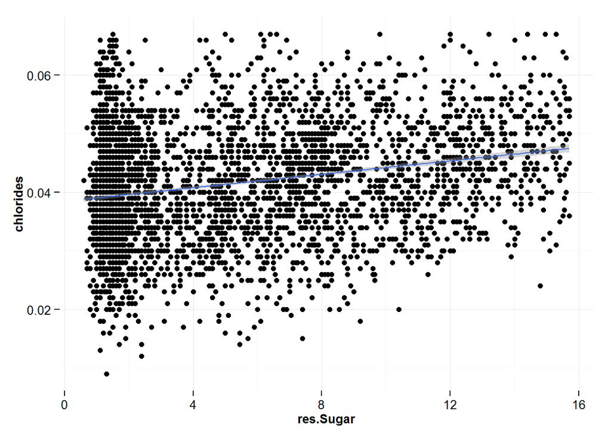

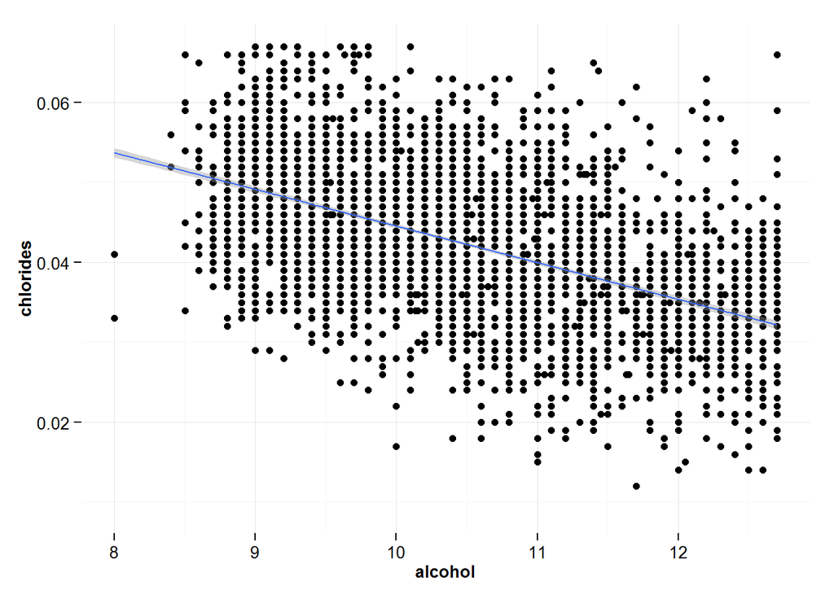

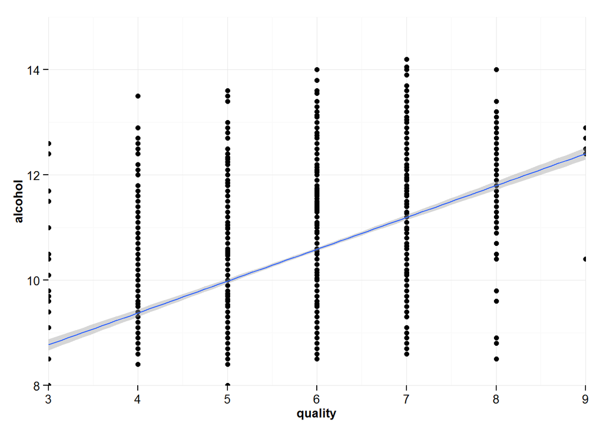

The plot shows that alcohol alone cannot be contributed to high quality. Hence in the multivariate scetion I will use alcohol with other vraibles along with quality

#### Bivariate Analysis

#### Talk about some of the relationships you observed in this part of the investigation. How did the feature(s) of interest vary with other features in the dataset?

With ggpair I was able to draw the correlation between a few variables which I had all plotted above. I had no real expectations with regards to the impact of other variables on the density, there are many variables which are significantly correlated to the density of wine.

#### Did you observe any interesting relationships between the other features (not the main feature(s) of interest)?

Another scatter plot with Chlorides is with Density and also with Alcohol. There seems to be a linear distribution, however few Chlorides surprisingly have high between density .995 and 1. It is not clear as to why a dozen of observations have high level of Chlorides.

#### What was the strongest relationship you found?

```
##    Min. 1st Qu.  Median    Mean 3rd Qu.    Max.
##  0.9871  0.9917  0.9937  0.9940  0.9961  1.0390
```

```
##    Min. 1st Qu.  Median    Mean 3rd Qu.    Max.
## 0.00900 0.03600 0.04300 0.04577 0.05000 0.34600
```

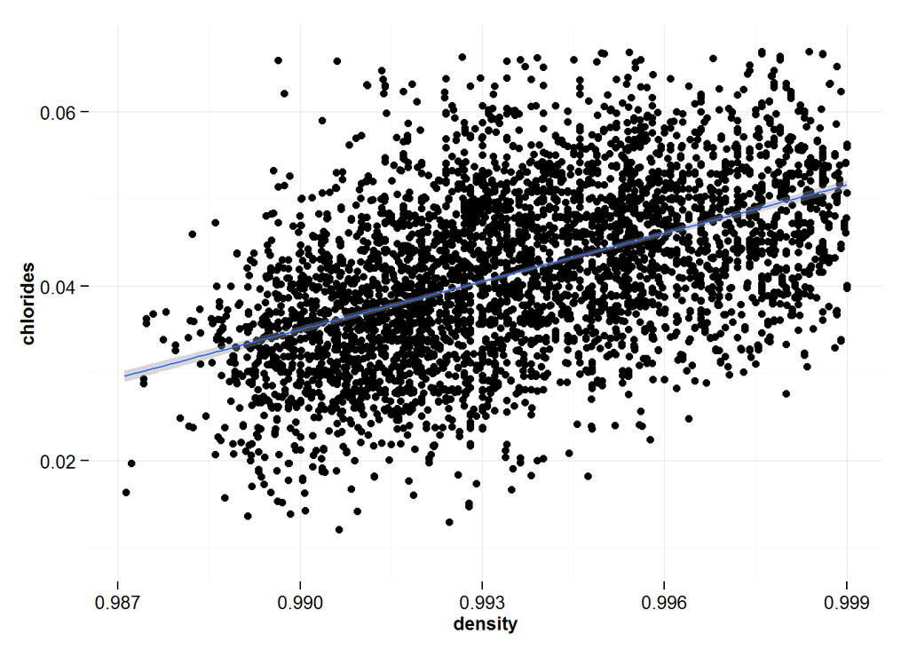

#### Multivariate Plots Section

I was able to identify the highest correlation coefficients between quality,density and the other variables available in our dataset. I decided to use density and the corelated variables to understand the quality of wine. The legend on the right indicates the color for each score.

Variables involved are:

Alcohol density Residual Sugar

```
##  [1] "X"                    "Facidity"             "Vacidity"
##  [4] "citric"               "res.Sugar"            "chlorides"
##  [7] "FSo2"                 "TSo2"                 "density"
## [10] "pH"                   "sulphates"            "alcohol"
## [13] "quality"              "bound.sulfur.dioxide"
```

```
##    Min. 1st Qu.  Median    Mean 3rd Qu.    Max.
##  0.9871  0.9917  0.9937  0.9940  0.9961  1.0390
```

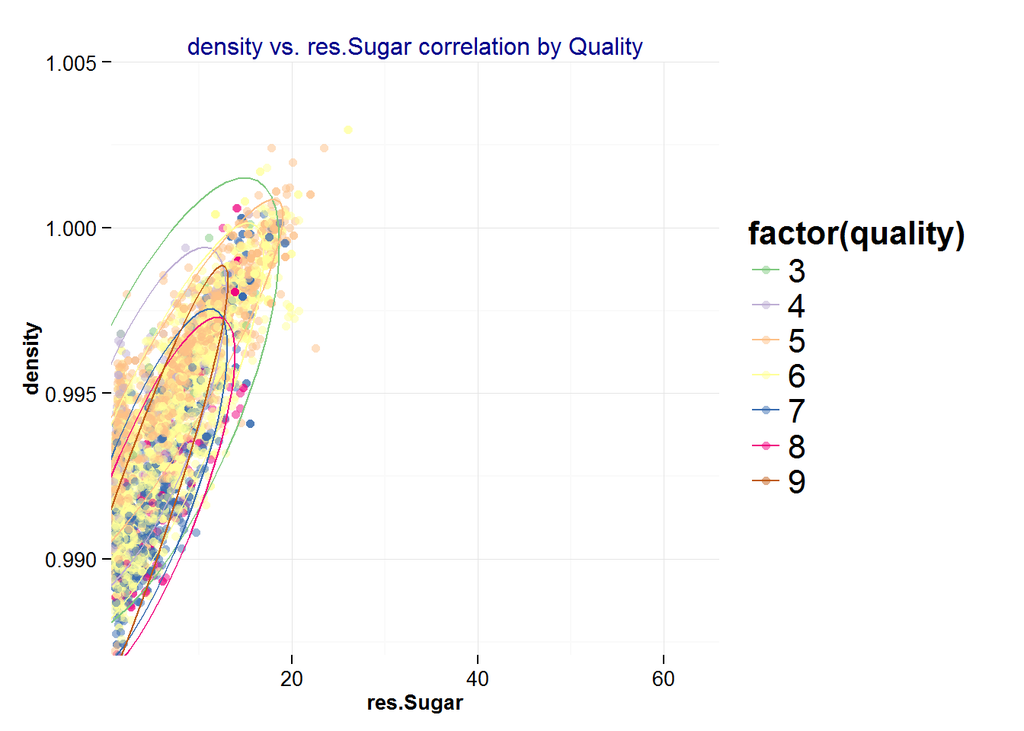

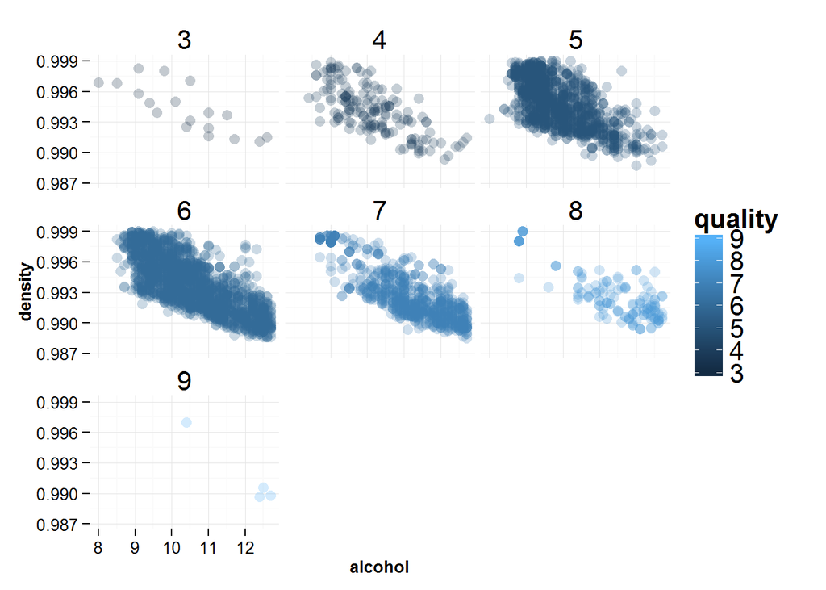

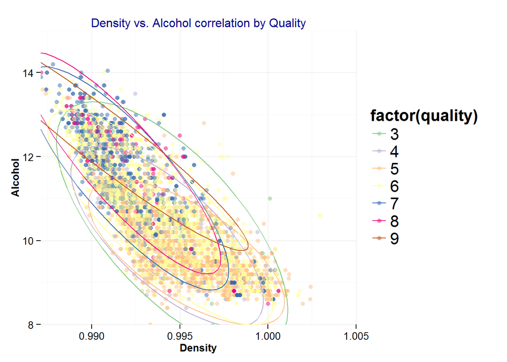

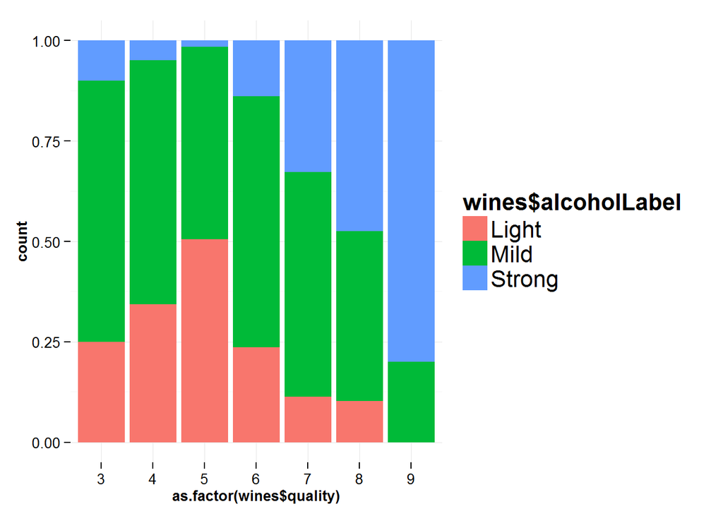

In the above stacked bar, for the higher quality wines there is more chance that the wine has higher alcohol percentage. There seems to be a correlation between density and alcohol . Less dense, more alcohol which also seems to be great wines .

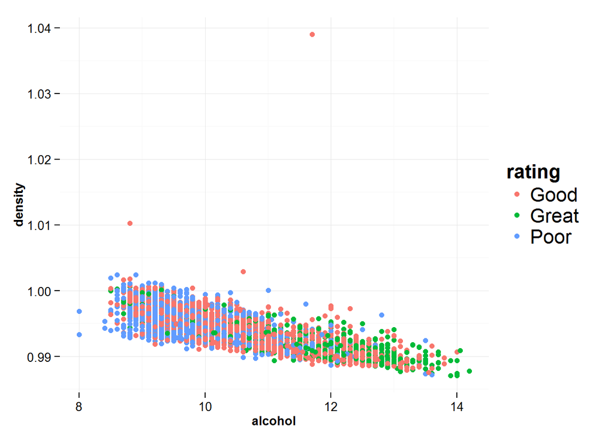

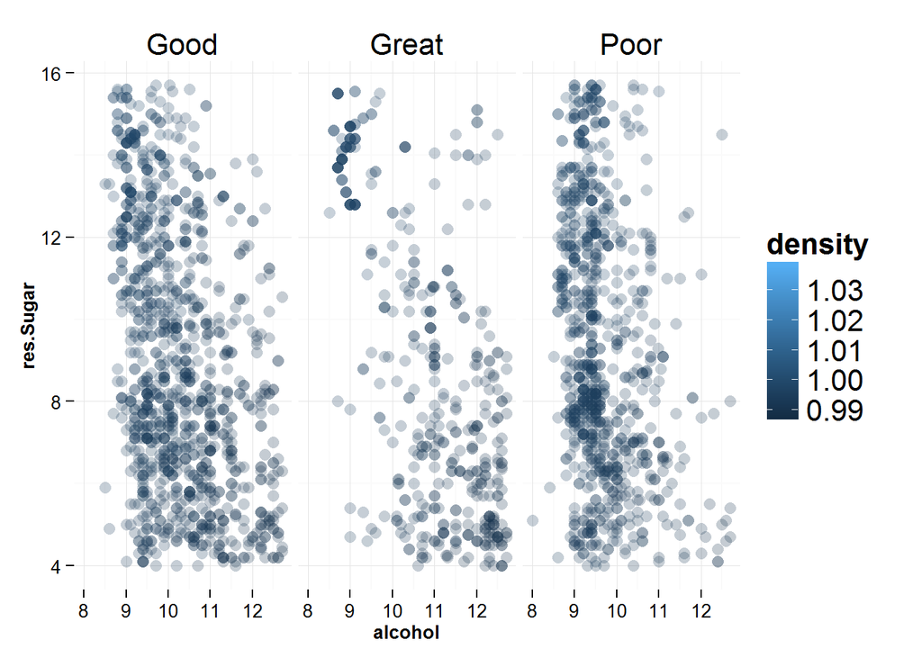

#### Multivariate Analysis

#### Talk about some of the relationships you observed in this part of the investigation. Were there features that strengthened each other in terms of looking at your feature(s) of interest?

According to the above scatter plot, there seems to be a relationship between alcohol and rating of the wine. most of great wines are in the right side of the plot. More specifically, if the alcohol percentage is above 11% there seems to be a good chance that we will have a good or great wine (great wine has rating 7 or above, good ones has quality above 5). If it is more than 12% the chance is even higher.

“Light”: Alcohol percentage below 10% “Mild” : Alcohol percentage higher than 10% but below 12% “Strong”: Alcohol percentage higher than 12%

The qulaity of wine is great if the alcohol content is between 12 and 14 . Based on my analysis we can that :

Less residual sugar with Alcohol between 12 and 14 with less density is considered great quality

#### Were there any interesting or surprising interactions between features?

```
##    Min. 1st Qu.  Median    Mean 3rd Qu.    Max.
##     4.0    78.0   100.0   103.1   125.0   331.0
```

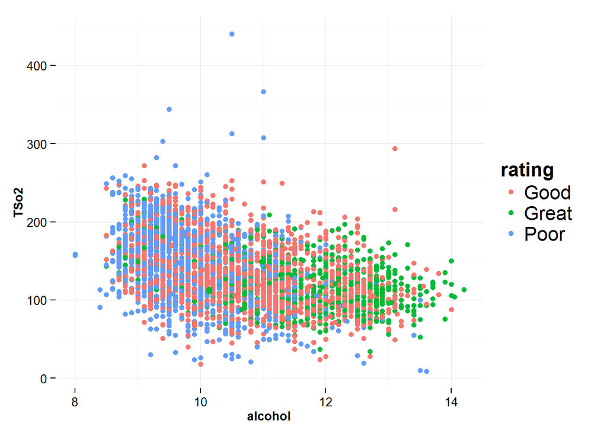

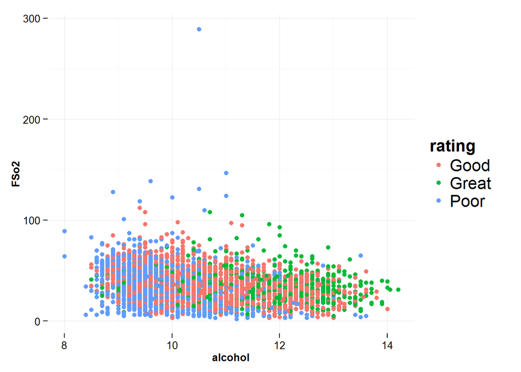

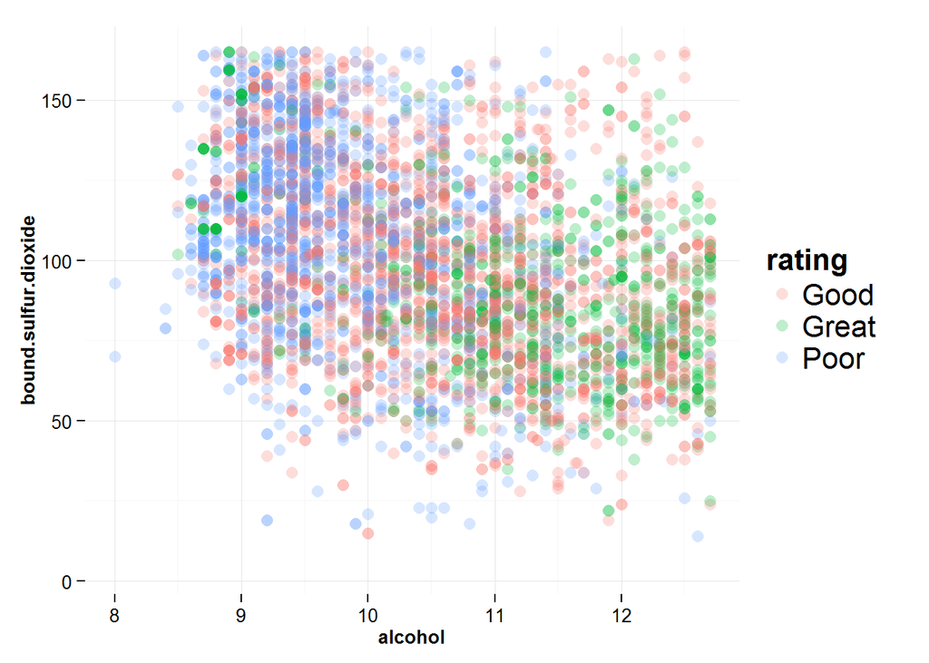

OPTIONAL: Did you create any models with your dataset? Discuss the strengths and limitations of your model.

#### Final Plots and Summary

#### Plot One

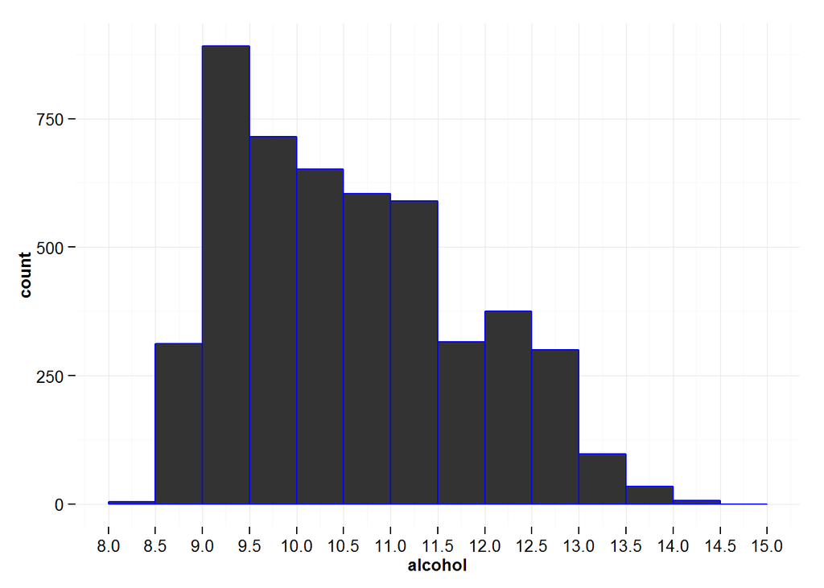

#### Plot Two

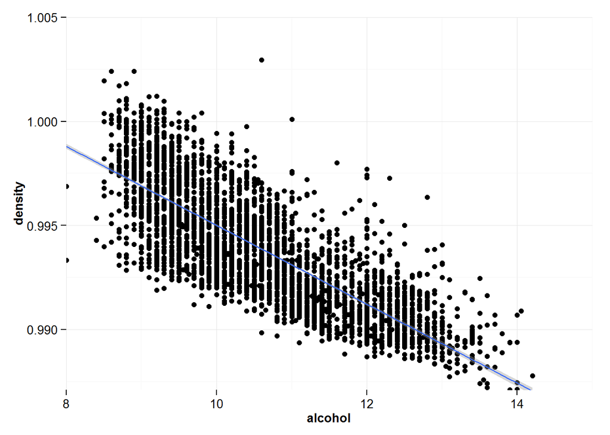

#### Plot Three

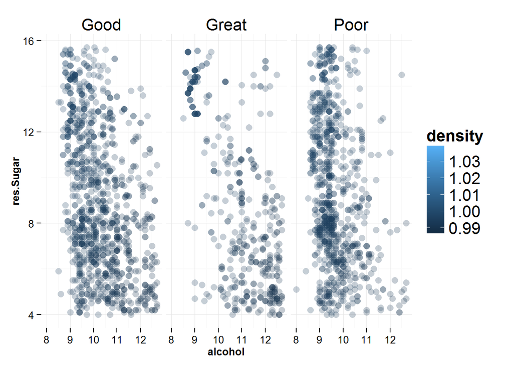

#### Description Three

From the Multivariate plot section I found a good correlation between alcohol,density,residual sugar by which the quality could also be determined. Hence it became clear from the dataset that Less dense and less residual sugar and alcohol in the range 10-14 are considered to be of great quality ——

#### Reflection

Assuming we can trust the data, there are some interesting illuminations. More alcohol is associated with higher quality wines, density can fairly well predicted by the chemical information in the data set. One important factor that contributes to Alcohol percentage is the remaining sugar in wine after fermentation so that the more sugar left after fermentation, the less the percentage of alcohol will be in the wine.

Analyzing the data the following conclusion:

When alcohol percentage decreases, density grows. Total sulfur dioxide and level of residual sugar are positively correlated. White wine density and residual sugar level have positive correlation. Alcohol level of wine decreases with the growth of residual sugar level. Wine with high alcohol percentage has quality level 7, wine with less alcohol percentage is quality level 5. Mostly frequent quality levels of white wine are 5 and 6.

Success Factor with dataset: I can still judge a wine quality (to some extent) with very technical variables without the need to actually taste it. It must provide the wine maker some sort of guidance towards how to produce a better wine. From the highest correlation coefficient, I can see that Alcohol plays a big part, therefore the wine makers must try to find techniques in order to increase the alcohol degree towards 14 and also decrease the volatile acidity (negative correlation).

Though I was able to judge the impact analysis on quality of wine, it would have been complete if more data was available. The biggest struggle was to analyse every correlated varaible ass the variables were all very close. I would be able to produce a better model as there’s a lot of impactful data that were not available in this dataset such as :

Grape Types

Year

Region